# Executive Summary

### 👇🏾Let's take a quick peek at the data.👇🏾

```python
member_engagement = pd.read_csv('member_engagement.csv')
```

```python
#this is just to take a look at the data
member_engagement.describe()
```

|  | ib_call_count | ob_call_count | ob_call_answered_count | ib_message_count | ob_message_count | ob_message_read_count | login_count | telemedicine_count | search_count | grievance_count |
| --- | --- | --- | --- | --- | --- | --- | --- | --- | --- | --- |
| count | 351362.000000 | 351362.000000 | 351362.000000 | 351362.000000 | 351362.000000 | 351362.000000 | 351362.000000 | 351362.000000 | 351362.000000 | 351362.000000 |
| mean | 0.228969 | 0.038738 | 0.007368 | 0.144577 | 0.163319 | 0.134064 | 1.114802 | 0.027308 | 0.320049 | 0.007684 |
| std | 0.806874 | 0.353109 | 0.094743 | 0.956451 | 0.782292 | 0.745294 | 2.917814 | 0.191751 | 1.377393 | 0.099852 |
| min | 0.000000 | 0.000000 | 0.000000 | 0.000000 | 0.000000 | 0.000000 | 0.000000 | 0.000000 | 0.000000 | 0.000000 |
| 25% | 0.000000 | 0.000000 | 0.000000 | 0.000000 | 0.000000 | 0.000000 | 0.000000 | 0.000000 | 0.000000 | 0.000000 |
| 50% | 0.000000 | 0.000000 | 0.000000 | 0.000000 | 0.000000 | 0.000000 | 0.000000 | 0.000000 | 0.000000 | 0.000000 |
| 75% | 0.000000 | 0.000000 | 0.000000 | 0.000000 | 0.000000 | 0.000000 | 1.000000 | 0.000000 | 0.000000 | 0.000000 |
| max | 90.000000 | 15.000000 | 4.000000 | 62.000000 | 40.000000 | 40.000000 | 108.000000 | 6.000000 | 36.000000 | 2.000000 |

```python
member_engagement.dtypes
```

```
member_id                 object
policy_id                 object
month                     object
policy_relation           object
age_group                 object
region                    object
enrollment_type           object
ib_call_count              int64
ob_call_count              int64
ob_call_answered_count     int64
ib_message_count           int64
ob_message_count           int64
ob_message_read_count      int64
login_count                int64
telemedicine_count         int64
search_count               int64
grievance_count            int64
dtype: object
```

```python
member_engagement.enrollment_type.unique()
```

```
array(['Off Exchange', 'On Exchange'], dtype=object)
```

```python
member_engagement.policy_relation.unique()
```

```
array(['Subscriber', 'Dependent', 'Spouse'], dtype=object)
```

```python
member_engagement.region.unique()
```

```
array(['New York', 'Orlando', 'San Antonio', 'Austin', 'New Jersey'],
      dtype=object)
```

```python
member_engagement.month.unique()
```

```
array(['2017-01-01', '2017-02-01', '2017-03-01', '2017-04-01',
       '2017-05-01', '2017-06-01', '2017-07-01', '2017-08-01',
       '2017-09-01', '2017-10-01', '2017-11-01', '2017-12-01',
       '2019-01-01', '2019-02-01', '2019-03-01', '2019-04-01',
       '2019-05-01', '2019-06-01', '2018-01-01', '2018-02-01',
       '2018-03-01', '2018-04-01', '2018-05-01', '2018-06-01',
       '2018-07-01', '2018-08-01', '2018-09-01', '2018-10-01',
       '2018-11-01', '2018-12-01'], dtype=object)
```

```python
member_engagement.sample(4)
```

|  | member_id | policy_id | month | policy_relation | age_group | region | enrollment_type | ib_call_count | ob_call_count | ob_call_answered_count | ib_message_count | ob_message_count | ob_message_read_count | login_count | telemedicine_count | search_count | grievance_count |
| --- | --- | --- | --- | --- | --- | --- | --- | --- | --- | --- | --- | --- | --- | --- | --- | --- | --- |
| 145277 | 28193a93-0caa-4e06-b4c1-831c328d8ece | 33b792fe-d263-4466-8b5b-f388a2c740c9 | 2019-01-01 | Spouse | 36-45 | New York | On Exchange | 0 | 0 | 0 | 0 | 0 | 0 | 3 | 0 | 2 | 0 |
| 307812 | a4637f25-1c78-4bfd-829e-0e34e9be82e8 | 6dbbfc8b-3be5-41ef-9adb-fa819a2ca889 | 2019-05-01 | Subscriber | 36-45 | Orlando | On Exchange | 0 | 0 | 0 | 0 | 0 | 0 | 8 | 1 | 1 | 0 |
| 151349 | 185aeac7-f717-42ca-9152-c08f952229e0 | b6e95fbd-6358-4506-9d6c-43e4582f9f8d | 2018-04-01 | Subscriber | 56+ | San Antonio | On Exchange | 1 | 0 | 0 | 0 | 0 | 0 | 0 | 0 | 0 | 0 |
| 228915 | d391bdce-70f5-4a0e-9f5a-0acfe6cd3d0a | d7841194-a7e5-43cf-92e6-b93f9117cb59 | 2019-04-01 | Subscriber | 27-35 | New York | Off Exchange | 0 | 0 | 0 | 0 | 0 | 0 | 5 | 1 | 1 | 0 |

Back to Top

## 🔬 Introducing My Function: K-Means-THINK_Binary 🔬

- Special thanks to [Jake VanderPlas](https://github.com/jakevdp) for inspiring me and showing the foundational code.

```python
def k_means_think_binary(sigma):
    super_peeps =  member_engagement[
    (np.abs(member_engagement.login_count-\
                    member_engagement.login_count.mean())\
       >= (sigma*member_engagement.login_count.std()))
                                 |\
      (np.abs(member_engagement.ib_call_count-\
                    member_engagement.ib_call_count.mean())\
       >= (sigma*member_engagement.ib_call_count.std()))
                                ]
    super_peeps = super_peeps[['login_count','ib_call_count']]
    kmeans = KMeans(n_clusters=2)
    kmeans.fit(super_peeps)
    y_kmeans = kmeans.predict(super_peeps)
    #y_kmeans = ['Loves To Call, But Not Online' if x == 0 else 'Always Online, Never Calls' for x in y_kmeans]
    if sigma < 3: #this is a hacky bit to make sure the legend colors are correctly assigned
        y_kmeans = ['Loves To Call, But Not Online' if x == 0 else 'Always Online, Never Calls' for x in y_kmeans]
                #^^^thanks to @arboc, https://stackoverflow.com/a/4406777/11736959
        sns.set_palette("husl", 8)
    #elif sigma in (3,10,15):
     #   y_kmeans = ['Loves To Call, But Not Online' if x == 1 else 'Always Online, Never Calls' for x in y_kmeans]
                #^^^thanks to @arboc, https://stackoverflow.com/a/4406777/11736959
      #  sns.set_palette("Set2")
    else:
        y_kmeans = ['Loves To Call, But Not Online' if x == 1 else 'Always Online, Never Calls' for x in y_kmeans]
                #^^^thanks to @arboc, https://stackoverflow.com/a/4406777/11736959
        flatui = ["#9b59b6", "#3498db", "#95a5a6", "#e74c3c", "#34495e", "#2ecc71"]
        sns.set_palette(flatui)
    super_peeps['Classification Concept'] = y_kmeans
    super_peeps
    #sns.set_palette("Paired")
    #sns.set_palette("husl", 8)
    sns.lmplot( x="login_count", y="ib_call_count", data=super_peeps, fit_reg=False, hue="Classification Concept", \
               legend=True, legend_out=True)
    #plt.legend(loc='upper right')
    user_count = super_peeps.login_count.count()
    plt.ylabel('Number of Inbound Calls Per Month')
    plt.xlabel('Number of Customer Logins Per Month')
    plt.suptitle('For Users With Inbound Calls or Logins Above {}σ'.format(sigma),\
              fontweight = 'bold', y=1.05)
    plt.title('                              {:,} customers'.format(user_count))
    plt.savefig('analyzer_{}-std-kmeans.png'.format(sigma),dpi=400, bbox_inches='tight')
    plt.ylim(top=30, bottom=0)
    plt.xlim(right=80, left=0)
    plt.show()
```

Back to Top

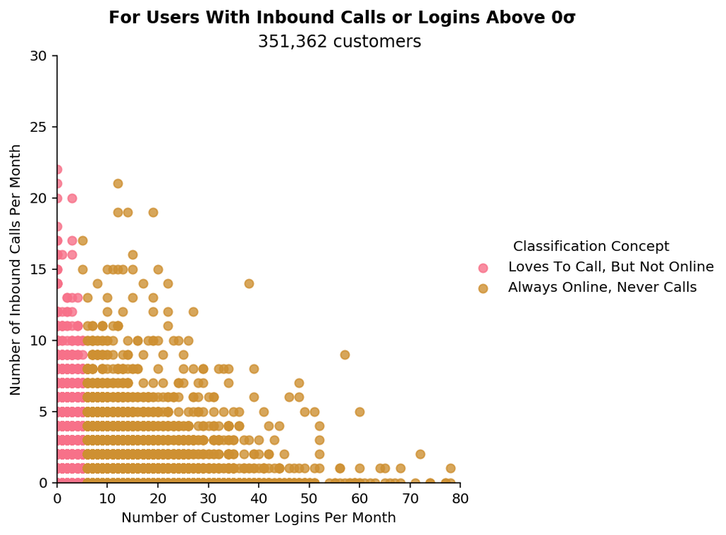

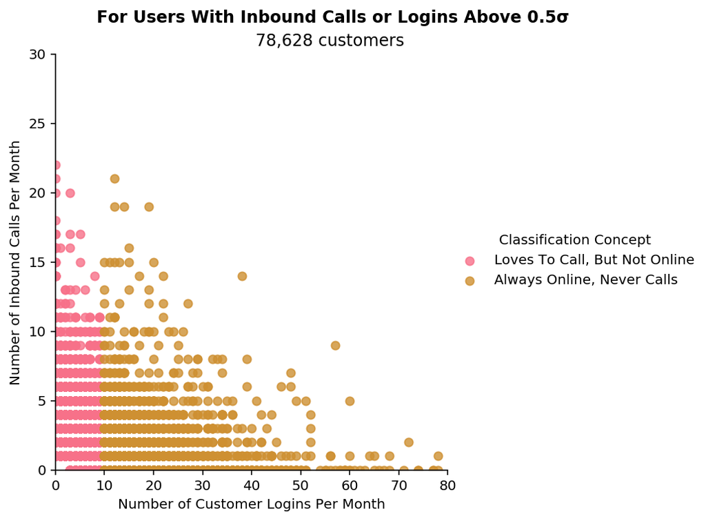

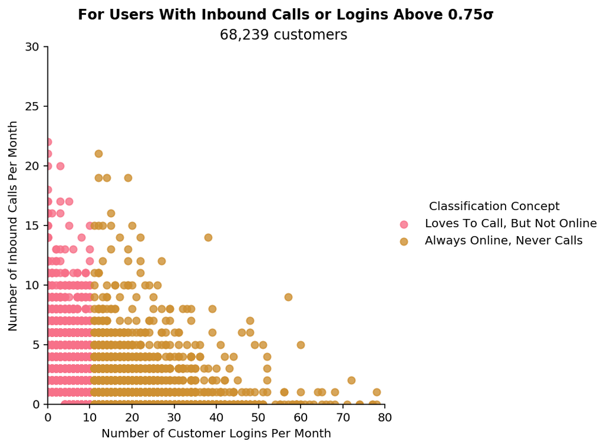

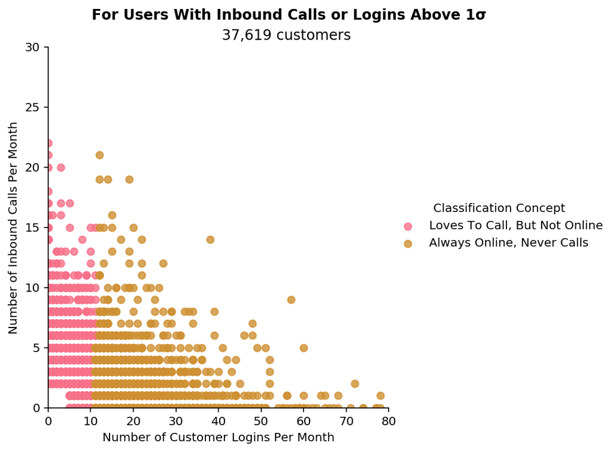

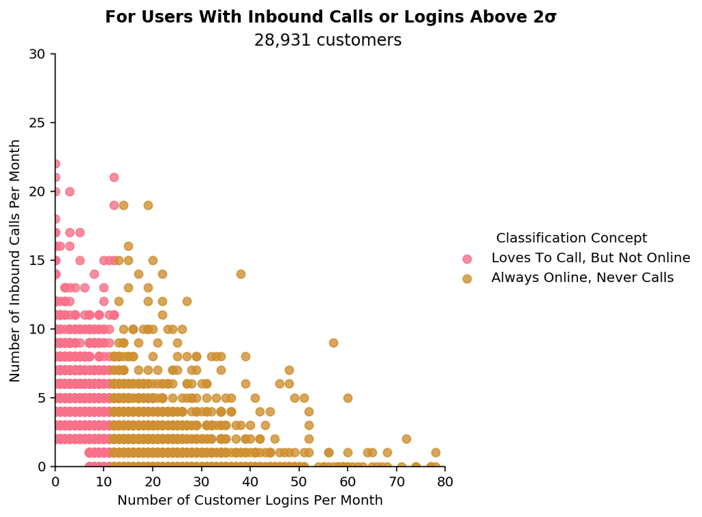

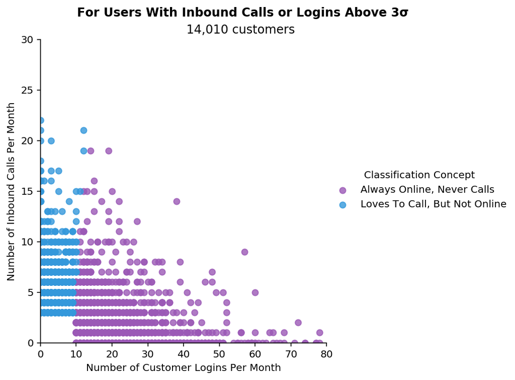

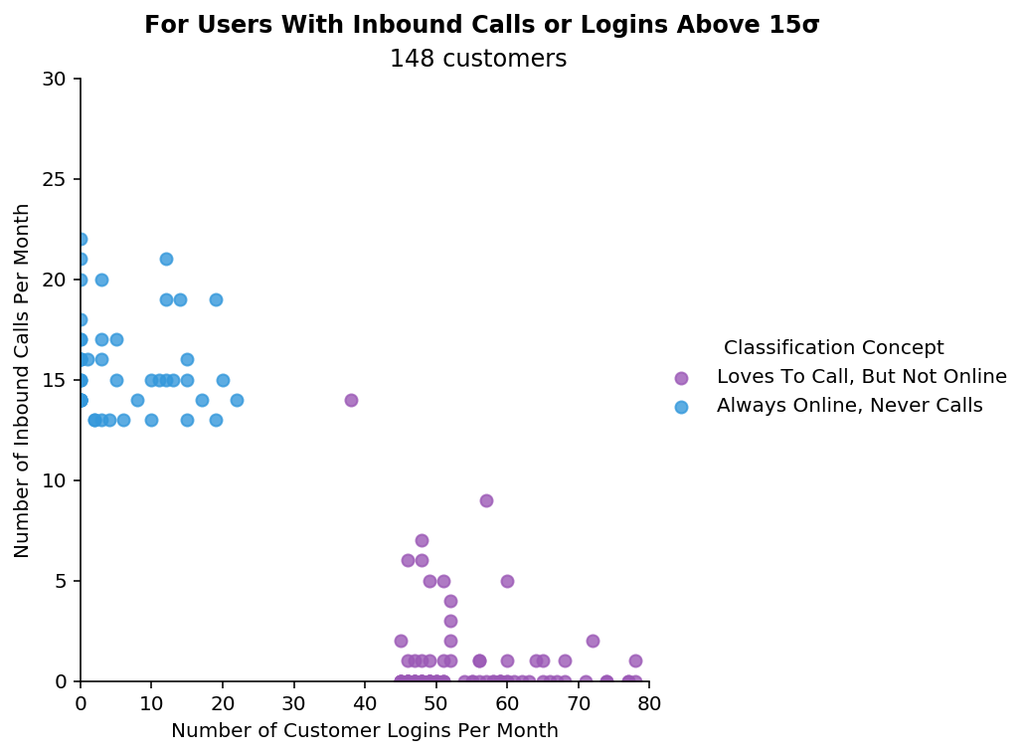

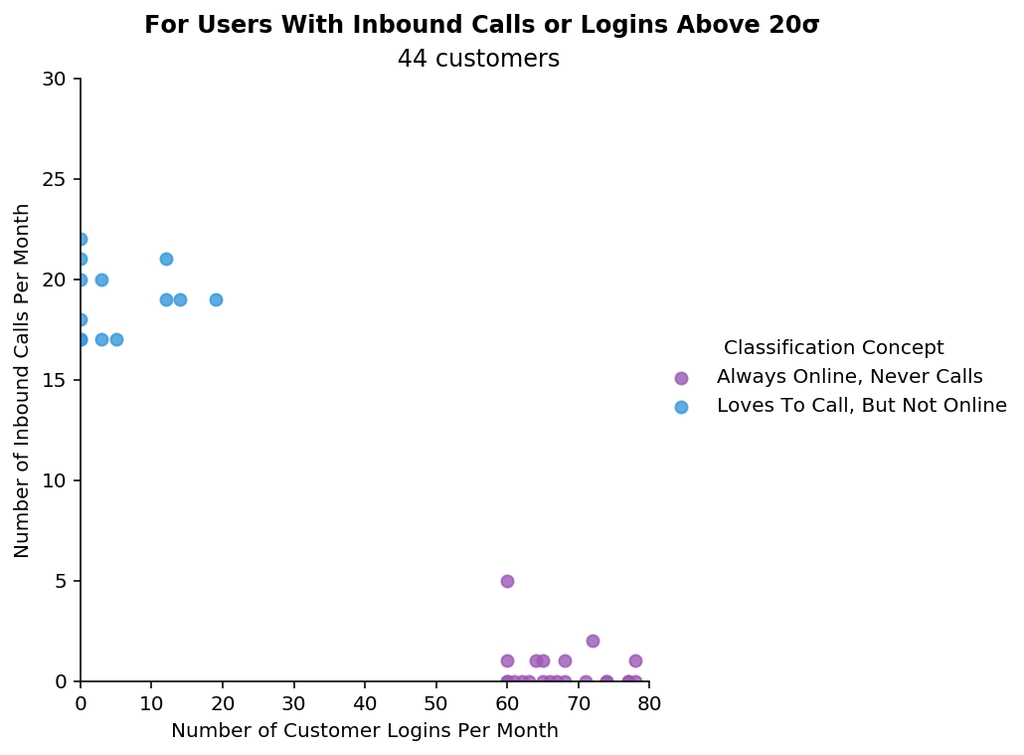

```python
for standard_deviation in [0,0.5,0.75,1,2,3,15,20]:
        k_means_think_binary(standard_deviation)
```

### 👆🏾Look out for this! 👆🏾

- Sometimes K-means alters the 1 or 0 it is using for classification, and throws off the labels in the legend.
- The left side is of this graph is always 'Loves To Call, But Not Online'
  - the right side of this graph is always 'Always Online, Never Calls'
  - But sometimes the K-means ML algorithm swaps the identifiers
- So just please be aware that the labels may get swapped once in a while, randomly.

Back to Top

# Step 2 - Further Exploration

- This takes the same function written above, and one-by-one, breaks it down across different categorical variables in the userbase.
- This is a foundation for further analysis.

Back to Top

## 🔬 Introducing My Other Function: The Analyzer 🔬

- Special thanks to [Jake VanderPlas](https://github.com/jakevdp) for inspiring me and showing the foundational code.

```python
def the_analyzer(num, groupby):
    super_peeps =  member_engagement[
    (np.abs(member_engagement.login_count-\
                    member_engagement.login_count.mean())\
       >= (num*member_engagement.login_count.std()))
                                 |\
      (np.abs(member_engagement.ib_call_count-\
                    member_engagement.ib_call_count.mean())\
       >= (num*member_engagement.ib_call_count.std()))
                                ]
    sns.set_palette("Dark2")
    sns.lmplot( x="login_count", y="ib_call_count", data=super_peeps, fit_reg=False, hue=groupby, \
               legend=True)
    user_count = super_peeps.member_id.count()
    plt.ylabel('Number of Inbound Calls Per Month')
    plt.xlabel('Number of Customer Logins Per Month')
    plt.suptitle('            For Users With Inbound Calls or Logins Above {}σ'.format(num),\
              fontweight = 'bold', y=1.05)
    plt.title('     {:,} customers'.format(user_count))
    plt.savefig('analyzer_{}-std_{}-groupby.png'.format(num, groupby),dpi=400, bbox_inches='tight')
    plt.ylim(top=30, bottom=0)
    plt.xlim(right=80, left=0)
    plt.show()
```

Back to Top

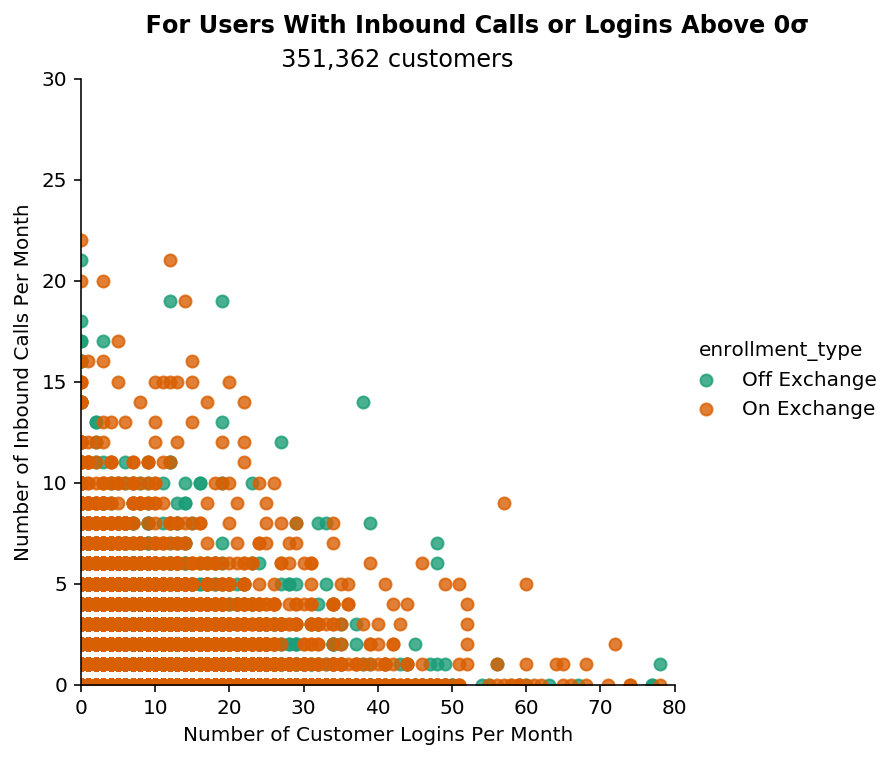

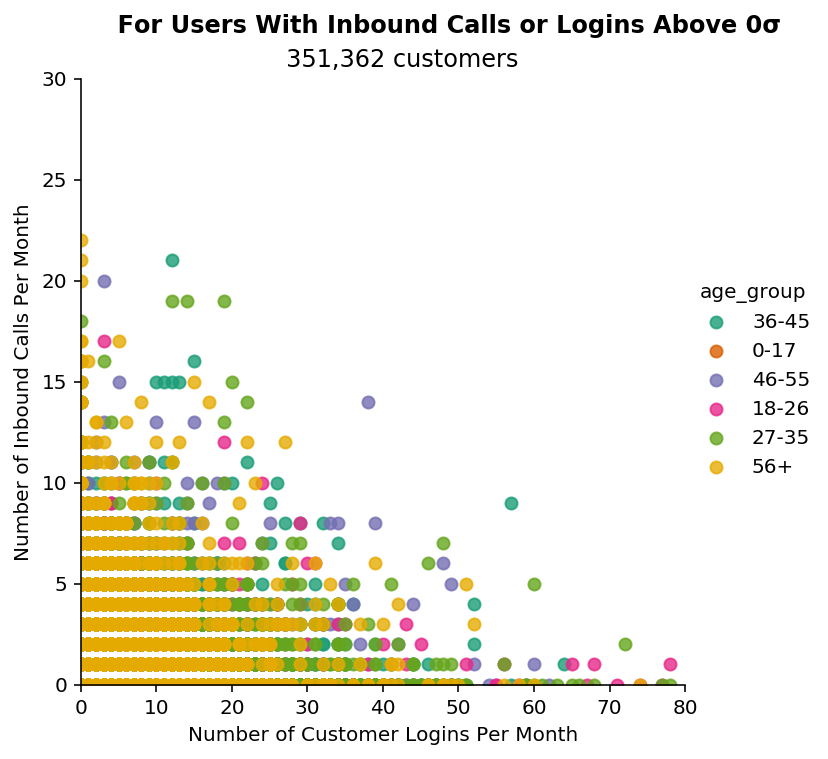

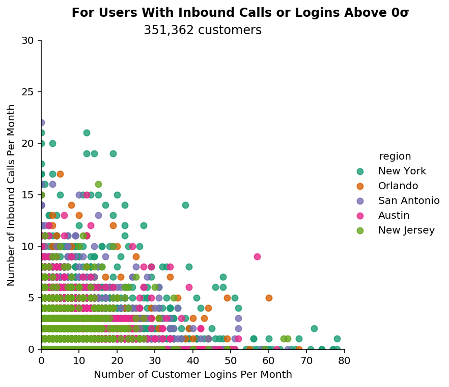

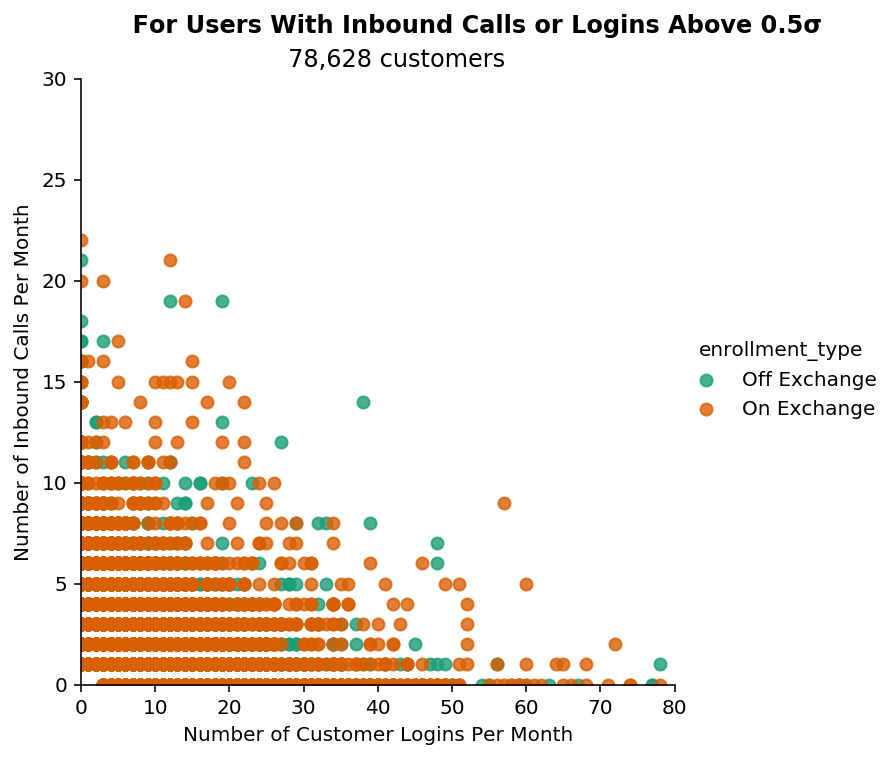

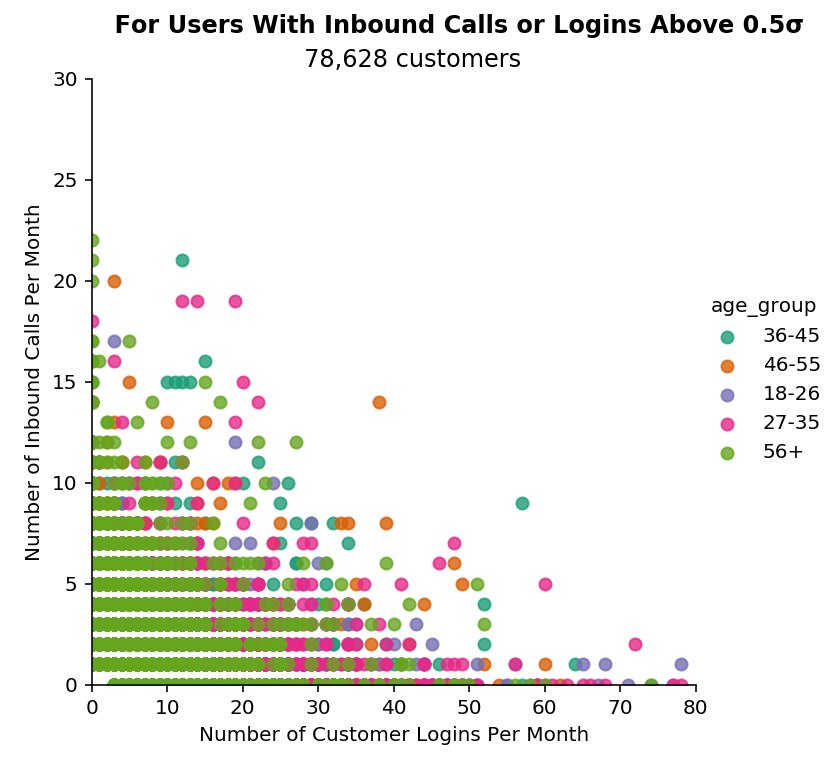

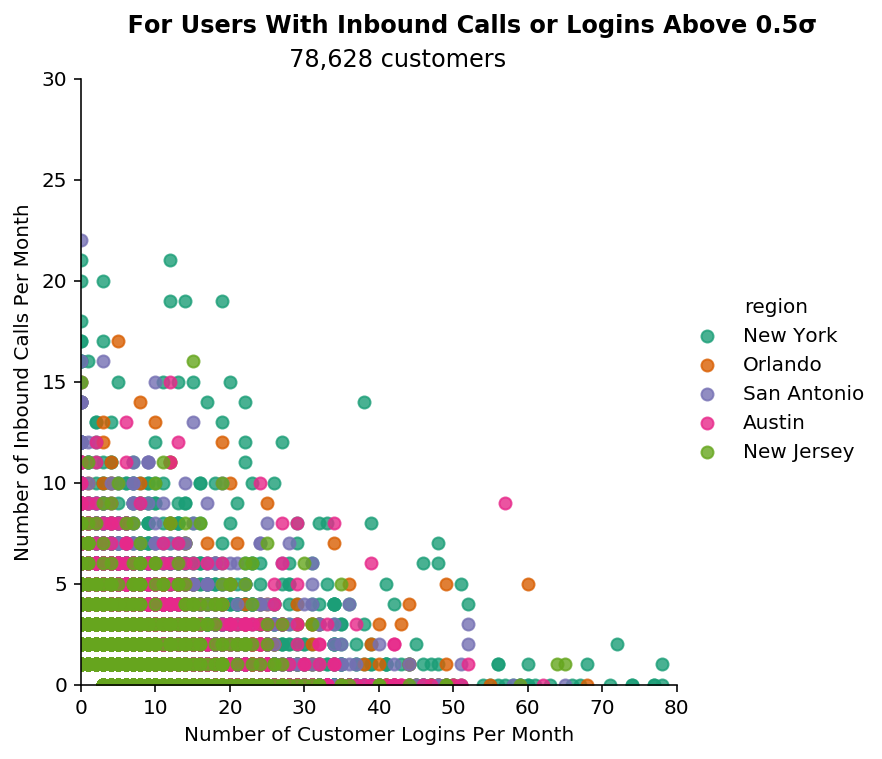

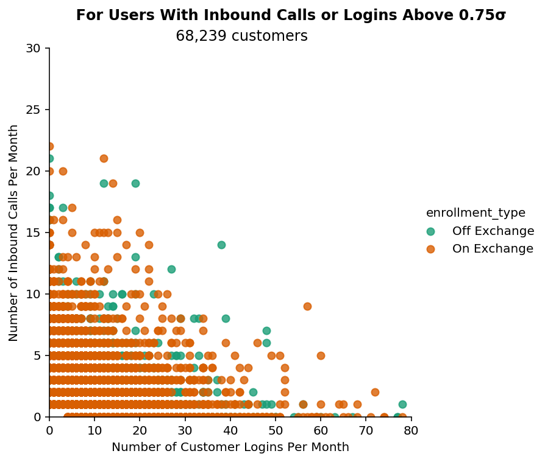

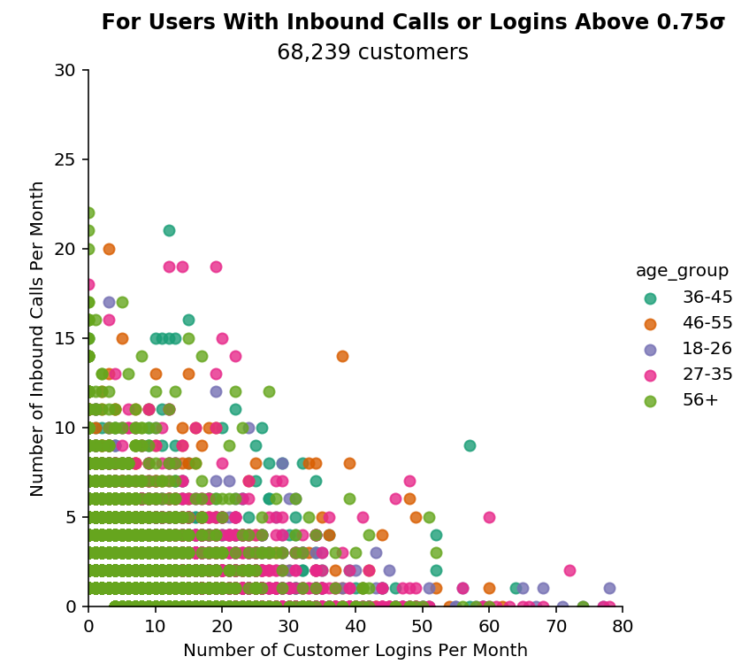

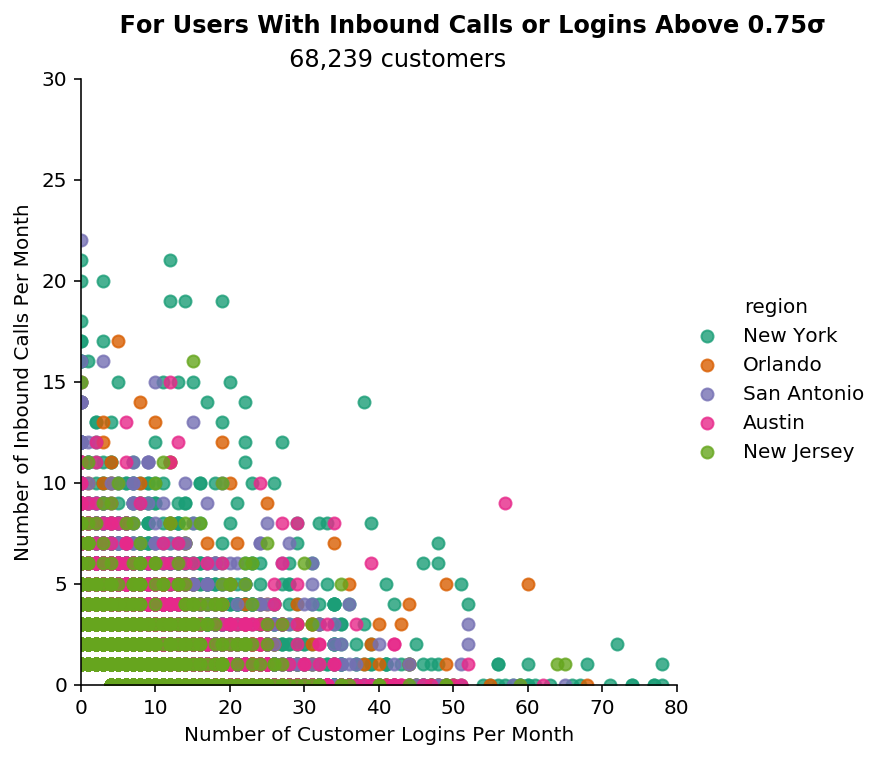

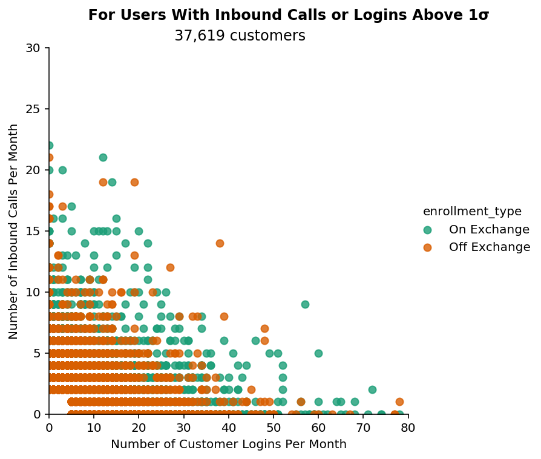

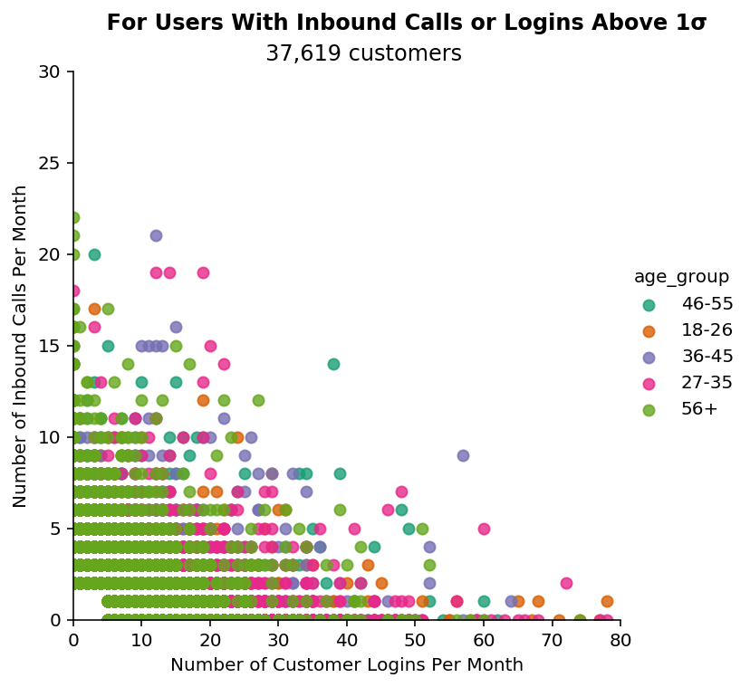

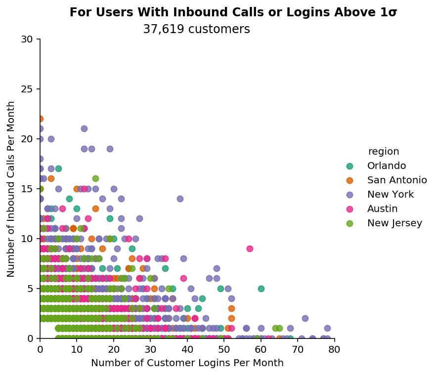

[15 more figures not shown]

```python
for i in [0,0.5,0.75,1,2,3,10,15, 20]:
    for q in ['enrollment_type', 'age_group', 'region']:
        the_analyzer(i, q)
```

Back to Top

# Thank you so much for your time and consideration!

## George John Jordan Thomas Aquinas Hayward, Optimist

[figure not shown]

[#TheLordAlwaysDelivers](https://youtu.be/in2MOJ-Hb8g)